# County Presidential Voting Patterns: 2016, 2020, and 2024

2026-03-23

## Introduction

In this post, we track **how U.S. counties voted across the last three presidential elections**—2016, 2020, and 2024—grouping them by their sequence of party winners and mapping the results. We then look at the shift in Democratic two-party vote share from 2020 to 2024, analyzing the scale of the erosion and how it varied across different turnout levels.

## Data

Election results come from the [`tonmcg/US_County_Level_Election_Results_08-24`](https://github.com/tonmcg/US_County_Level_Election_Results_08-24) repository, which provides **county-level presidential returns from 2008 to 2024**. County geometries are downloaded via `tigris`.

```r
pacman::p_load(dplyr, tidyr, ggplot2, tigris, sf, scales, forcats, DT, stringr, ggrepel)
```

```r
conus <- c(setdiff(state.abb, c("AK", "HI")))

counties_sf <- tigris::counties(cb = TRUE, resolution = "20m", year = 2020) |>
  filter(STUSPS %in% conus) |>
  sf::st_transform(5070) |>
  select(GEOID, geometry)

states_sf <- tigris::states(cb = TRUE, resolution = "20m", year = 2020) |>
  filter(STUSPS %in% conus) |>
  sf::st_transform(5070)

# tonmcg/US_County_Level_Election_Results_08-24
read_tonmcg <- function(file, yr) {
  df <- read.csv(file)
  fips_col <- if ("county_fips" %in% names(df)) "county_fips" else "combined_fips"
  state_col <- if ("state_name" %in% names(df)) "state_name" else "state_abbr"
  df |>
    mutate(GEOID = str_pad(.data[[fips_col]], 5, pad = "0"), year = yr) |>
    select(GEOID, year, democrat = votes_dem, republican = votes_gop,
           county_name, state = all_of(state_col))
}

base_url <- "https://raw.githubusercontent.com/tonmcg/US_County_Level_Election_Results_08-24/master/"

votes <- bind_rows(
  read_tonmcg(paste0(base_url, "2016_US_County_Level_Presidential_Results.csv"), 2016),
  read_tonmcg(paste0(base_url, "2020_US_County_Level_Presidential_Results.csv"), 2020),
  read_tonmcg(paste0(base_url, "2024_US_County_Level_Presidential_Results.csv"), 2024)
) |> filter(!str_sub(GEOID, 1, 2) %in% c("02", "15"),
            as.integer(str_sub(GEOID, 1, 2)) <= 56)
```

Sample from 2024; data structured identically for 2016 and 2020.

| GEOID | year | democrat | republican | county_name | state |
| --- | --- | --- | --- | --- | --- |
| 01001 | 2024 | 7439 | 20484 | Autauga County | Alabama |
| 01003 | 2024 | 24934 | 95798 | Baldwin County | Alabama |
| 01005 | 2024 | 4158 | 5606 | Barbour County | Alabama |
| 01007 | 2024 | 1619 | 7572 | Bibb County | Alabama |
| 01009 | 2024 | 2576 | 25354 | Blount County | Alabama |
| 01011 | 2024 | 2983 | 1101 | Bullock County | Alabama |
| 01013 | 2024 | 3251 | 5172 | Butler County | Alabama |
| 01015 | 2024 | 13194 | 34912 | Calhoun County | Alabama |
| 01017 | 2024 | 5405 | 8711 | Chambers County | Alabama |
| 01019 | 2024 | 1553 | 11358 | Cherokee County | Alabama |

[output cut: 90 more lines]

## Build Voting Categories

We pivot the data wide so each county has one column per election year, then concatenate the three results into a single label – e.g., `D-D-R` for a county that voted Democrat in 2016 and 2020 and flipped Republican in 2024.

```r
patterns <- votes |>
  mutate(party = ifelse(republican > democrat, "R", "D")) |>
  select(GEOID, year, party) |>
  pivot_wider(names_from = year, values_from = party, names_prefix = "y") |>
  filter(!is.na(y2016), !is.na(y2020), !is.na(y2024)) |>
  mutate(pattern = paste(y2016, y2020, y2024, sep = "-"))

label_map <- c(
  "R-R-R" = "Trump-Trump-Trump",
  "D-D-D" = "Clinton-Biden-Harris",
  "D-D-R" = "Clinton-Biden-Trump",   # held D through 2020, flipped R in 2024
  "R-D-R" = "Trump-Biden-Trump",     # flipped D in 2020, swung back in 2024
  "R-D-D" = "Trump-Biden-Harris",    # flipped D in 2020, held D in 2024
  "D-R-R" = "Clinton-Trump-Trump",   # flipped R in 2020, held R in 2024
  "R-R-D" = "Trump-Trump-Harris"     # held R through 2020, flipped D in 2024
)

pattern_counts <- patterns |>
  count(pattern, sort = TRUE) |>
  mutate(candidates = label_map[pattern])

DT::datatable(pattern_counts, rownames = FALSE,
              caption = "County counts by three-election voting pattern",
              options = list(pageLength = 10, dom = 't', scrollX = TRUE))
```

| pattern | n | candidates |
| --- | --- | --- |
| R-R-R | 2558 | Trump-Trump-Trump |
| D-D-D | 408 | Clinton-Biden-Harris |
| D-D-R | 54 | Clinton-Biden-Trump |
| R-D-D | 33 | Trump-Biden-Harris |
| R-D-R | 32 | Trump-Biden-Trump |
| D-R-R | 14 | Clinton-Trump-Trump |

## Map Voting Patterns

Each county is colored by its three-election voting sequence, from 2016 through 2024. **`R-R-R` and `D-D-D` together account for the large majority of counties**, with flip patterns scattered across competitive regions.

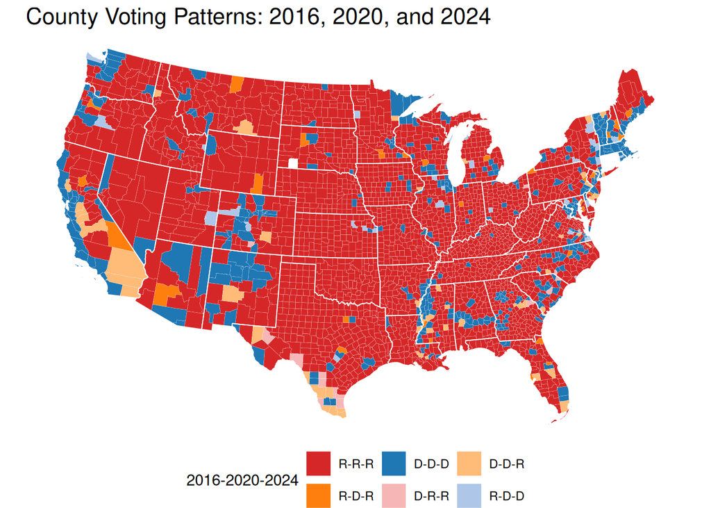

```r
map_data <- counties_sf |>
  left_join(patterns, by = "GEOID") |>
  filter(!is.na(pattern))

pattern_colors <- c(
  "R-R-R" = "#d62728",
  "R-D-R" = "#ff7f0e",
  "D-D-D" = "#1f77b4",
  "D-R-R" = "#f7b6b6",
  "D-D-R" = "#ffbb78",
  "R-R-D" = "#ffbb78",
  "D-R-D" = "#98df8a",
  "R-D-D" = "#aec7e8"
)

map_data |>
  mutate(pattern = factor(pattern, levels = names(pattern_colors))) |>
  ggplot() +
  geom_sf(aes(fill = pattern), color = "white", linewidth = 0.05) +
  geom_sf(data = states_sf, fill = NA, color = "white", linewidth = 0.3) +
  scale_fill_manual(
    values = pattern_colors,
    na.value = "grey85",
    name = "2016-2020-2024"
  ) +
  labs(title = "County Voting Patterns: 2016, 2020, and 2024") +
  theme_void() +
  theme(
    plot.title = element_text(size = 16),
    legend.position = "bottom"
  )
```

## Pattern Breakdown

The bar chart below shows the count of counties by voting pattern, ordered from most to least common. Beyond `R-R-R` and `D-D-D`:

- **`D-D-R`** (54 counties) – held Democratic through 2020, broke for Trump in 2024
- **`R-D-D`** (33 counties) – flipped Democratic in 2020 and held through 2024
- **`R-D-R`** (32 counties) – classic swing-back; briefly went for Biden in 2020, returned to Trump in 2024
- **`D-R-R`** (14 counties) – flipped Republican in 2020 and stayed there

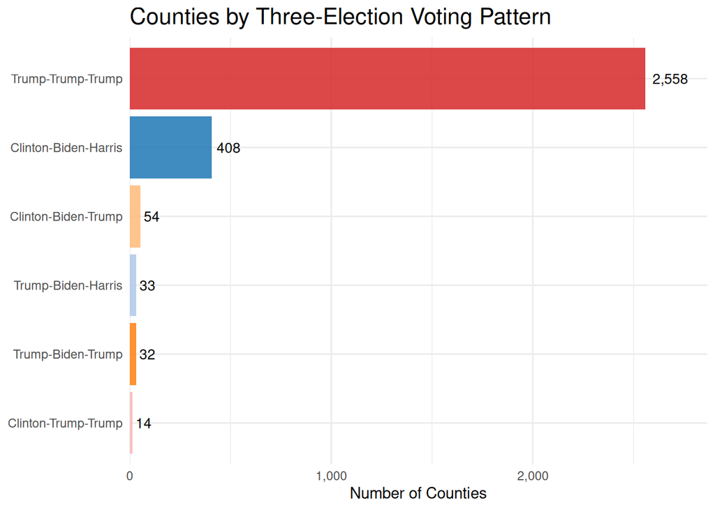

```r
patterns |>
  count(pattern) |>
  mutate(label = label_map[pattern],
         label = fct_reorder(label, n),              # order bars by count
         fill = pattern_colors[pattern]) |>          # match map colors
  ggplot(aes(x = label, y = n, fill = pattern)) +
  geom_col(alpha = 0.85) +
  geom_text(aes(label = comma(n)), hjust = -0.2, size = 3.5) +
  coord_flip() +
  scale_fill_manual(values = pattern_colors, breaks = names(pattern_colors)) +
  scale_y_continuous(labels = comma, expand = c(0, 0),
                     limits = c(0, max(pattern_counts$n) * 1.12)) +
  labs(title = "Counties by Three-Election Voting Pattern",
       x = NULL, y = "Number of Counties") +
  theme_minimal() +
  theme(legend.position = "none",
        plot.title = element_text(size = 16))
```

## Margin Shifts: 2020 to 2024

The map below shows the change in Democratic two-party vote share between 2020 and 2024; red indicates a shift toward Republicans, blue toward Democrats. **Nearly the entire map runs some shade of red**, with a handful of exceptions concentrated in the Mountain West.

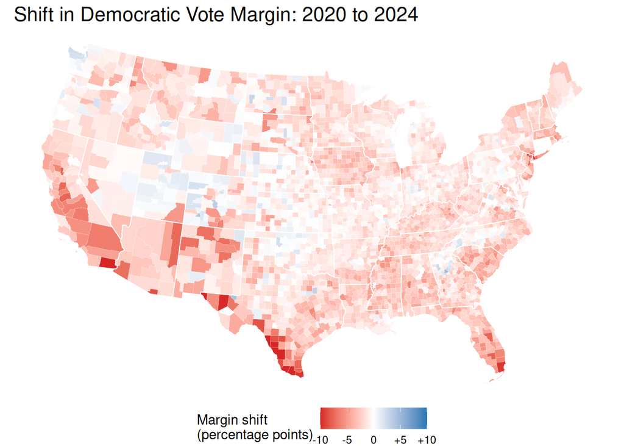

```r
margins <- votes |>
  filter(year %in% c(2020, 2024)) |>
  mutate(dem_2party = democrat / (democrat + republican) * 100) |>
  select(GEOID, year, dem_2party) |>
  pivot_wider(names_from = year, values_from = dem_2party, names_prefix = "dem_") |>
  mutate(shift = dem_2024 - dem_2020) |>
  filter(!is.na(shift))

counties_sf |>
  left_join(margins, by = "GEOID") |>
  filter(!is.na(shift)) |>
  ggplot() +
  geom_sf(aes(fill = shift), color = "white", linewidth = 0.05) +
  geom_sf(data = states_sf, fill = NA, color = "white", linewidth = 0.3) +
  scale_fill_gradient2(
    low = "#d62728", mid = "white", high = "#1f77b4",
    midpoint = 0, limits = c(-10, 10), oob = scales::squish,
    name = "Margin shift\n(percentage points)",
    labels = scales::label_number(style_positive = "plus")
  ) +
  labs(title = "Shift in Democratic Vote Margin: 2020 to 2024") +
  theme_void() +
  theme(plot.title = element_text(size = 16),
        legend.position = "bottom")
```

## Vote Shift by County Population

The map shows where the shift happened; the scatter below asks whether it was evenly distributed across county size. We use **total votes cast as a proxy for county population**. Each point is a county; the loess curve summarizes the relationship between county size and the scale of Harris’s underperformance relative to Biden.

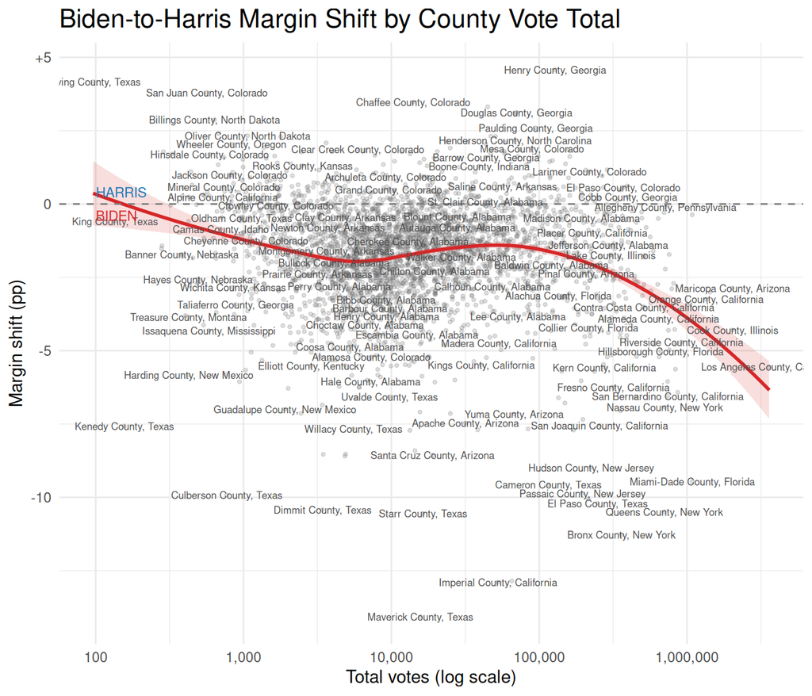

```r
scatter_data <- votes |>
  filter(year == 2024) |>
  mutate(total_votes = democrat + republican,
         label = paste0(county_name, ", ", state)) |>
  inner_join(margins |> select(GEOID, shift), by = "GEOID")

ggplot(scatter_data, aes(x = total_votes, y = shift)) +
  geom_point(alpha = 0.2, size = 0.8, color = "grey40") +
  geom_smooth(method = "loess", se = TRUE, color = "#d62728", fill = "#d62728", alpha = 0.15) +
  geom_hline(yintercept = 0, linetype = "dashed", color = "grey50") +
  geom_text(aes(label = label), size = 2.2, color = "grey30",
            check_overlap = TRUE) +
  annotate("text", x = 100, y = 0.4, label = "HARRIS", hjust = 0, size = 3, color = "#1f77b4") +
  annotate("text", x = 100, y = -0.4, label = "BIDEN", hjust = 0, size = 3, color = "#d62728") +
  scale_x_log10(labels = scales::comma) +
  scale_y_continuous(labels = scales::label_number(style_positive = "plus")) +
  labs(title = "Biden-to-Harris Margin Shift by County Vote Total",
       x = "Total votes (log scale)", y = "Margin shift (pp)") +
  theme_minimal() +
  theme(plot.title = element_text(size = 16))
```

## Summary

| Margin shift | Counties | Pct |
| --- | --- | --- |
| Harris < Biden: 0-2.5pp | 1949 | 62.9% |
| Harris < Biden: 2.5-5pp | 691 | 22.3% |
| Harris < Biden: >5pp | 103 | 3.3% |
| Harris > Biden | 357 | 11.5% |

While the flip patterns are notable, the margins map perhaps tells the more interesting story. **Harris underperformed Biden in 88% of counties**. This wasn’t a concentrated collapse, but a broad, shallow erosion; **63% of those counties saw a deficit within 2.5 percentage points**. Notably, the loess analysis shows that these losses were **even more pronounced in more populous counties** (as measured by total votes cast). Whether that scale of erosion is unusual, or simply what party transitions look like when measured against the unique Biden-Trump baseline, is a question not addressed here.